# R Notebook

# Aprendizaje estadístico

## Práctico 1a

Diploma Universitario en Ciencias Sociales Computacionales y Humanidades Digitales (UNSAM).

Módulo 3: Introducción al modelado de datos.

## Introducción a R - Comandos básicos

En *R* usamos *funciones* para realizar operaciones. Por ejemplo, para ejecutar una función llamada **funcname**, tipeamos **funcname(input1, intput2)**, donde *input* (también llamados *argumentos*) le dirá a *R* cómo ejecutar la función.

Veamos un ejemplo. Para crear un vector de números, usamos la función **c()** (la ‘c’ es por *concatenar*). Cualquier número dentro de estos paréntesis son agrupados conjuntamente.

A continuación agrupá los números 1, 3, 2 y 5 y guardalos como un *vector* llamado **x**.

```r
x <- c(1,3,2,5)
```

Corroborá en la próxima celda que la variable ‘x’ se asignó correctamente.

```r
x
```

```
[1] 1 3 2 5
```

A continuación, creá la variable ‘y’ concatenando los valores 1, 4 y 3. Luego, reasigná la variable ‘x’ y concatená los valores 1, 6 y 2.

```r
y = c(1,4,3)
x = c(1,6,2)
```

Ahora, usemos la función **length()** para verificar la longitud de los vectores ‘x’ e ‘y’. Ambos deberían tener la misma longitud.

```r
length(x)
```

```
[1] 3
```

```r
length(y)
```

```
[1] 3
```

Habiendo corroborado que los vectores tienen la misma longitud, vamos a sumarlos. Sumar los vectores hará que se sume el primer número de ‘x’ con el primer numero de ‘y’ y así sucesivamente.

```r
x+y
```

```
[1]  2 10  5
```

La función **ls()** nos permite ver una lista de todos los objetos (como por ejemplo datos y funciones) que hemos guardado hasta el momento. La función **rm()** elimina los objetos que le indiquemos.

A continuación, listemos los objetos usando **ls()**.

```r
ls()
```

```
[1] "x" "y"
```

Usando **rm()** borremos el vector ‘x’ y el vector ‘y’.

```r
rm(x,y)
```

Corroboremos, usando **ls()**, que los objetos han sido borrados.

```r
ls()
```

```
character(0)
```

Podemos tambien borrar todos los objetos en un solo comando usando **rm(list=ls())**

La función **matrix()** puede ser utilizada para crear una matriz de números.

A continuación, generemos una matriz de números (1, 2, 3, 4) de dos (2) filas y dos (2) columnas. La misma la asignamos a la variable ‘x’.

Si tenés dudas sobre como utilizar una función o qué argumentos acepta, recordá que anteponiendo un signo de interrogación podés acceder a la ayuda que brinda *R* sobre la función requerida. Por ejemplo, para acceder a la ayuda sobre la función **matrix()** ingresamos **‘?matrix’**. Probá ejecutando la celda aquí debajo:

```r
?matrix()
```

Ahora que sabemos como funciona matrix(), generemos la matriz.

```r
x = matrix(data=c(1,2,3,4), nrow=2, ncol=2)
x
```

```
     [,1] [,2]
[1,]    1    3
[2,]    2    4
```

Por defecto, la matriz que generamos usando **matrix()** se crea completando los valores por columnas, de manera alternativa podemos generar una matriz que complete valores por fila adicionando el parámetro **byrow=TRUE**.

Creemos ahora la misma matriz, con los mismos valores, pero ordenando el llenado de los datos por fila.

```r
x = matrix(data=c(1,2,3,4), nrow=2, ncol=2, byrow=TRUE)
x
```

```
     [,1] [,2]
[1,]    1    2
[2,]    3    4
```

¡Bien! Ahora vamos a utilizar la función **sqrt()**. La función se llama así dada la abreviación de su nombre en inglés (square root). Tal función sirve para calcular la raíz cuadrada de los parámetros que le suministremos.

Vamos a usar **sqrt()** con nuestra martriz de datos generada en la celda anterior.

```r
sqrt(x)
```

```
         [,1]     [,2]
[1,] 1.000000 1.414214
[2,] 1.732051 2.000000
```

Ahora vamos a usar la función **^2** para elevar al cuadrado a nuestra matriz, en realidad cualquier tipo de potencia está permitida, tanto fracciones como potencias negativas, en este caso solo queremos elevar al cuadrado.

Elevemos al cuadrado nuestra matriz ‘x’

```r
x^2
```

```
     [,1] [,2]
[1,]    1    4
[2,]    9   16
```

Ahora, vamos a utilizar la función **rnorm()**. Tal como se desprende de la documentación, **rnorm()** genera un vector de datos aleatorios sacados de una distribución normal, con el parámetro **n** especificamos el tamaño del vector que queremos generar. Cada vez que generemos un vector con **rnorm()** los valores cambiaran, ya que se generan de manera aleatorio

Por otro lado tenemos disponible la función **cor()** que computa la correlación entre dos variables.

A continuación vamos a crear un vector asignado a la variable ‘x’ usando **rnorm()** especificando una longitud de 50 elementos.

```r
x = rnorm(50)
x
```

```
 [1]  0.67661777 -1.55922206 -0.67038941  0.23339395 -1.29199065  0.15301803  1.61618504  0.73231265  1.74627556  0.26362743 -0.58340287
[12]  0.51013543 -1.87778111  0.01297929 -0.86368696  0.81436977  0.71128479 -1.32208736 -0.42810404 -1.83250647 -0.84313309 -0.59994980
[23]  0.68822965 -0.33596892 -1.38870785  0.61737205  1.33719690  1.11752300  0.13231406  1.51834576 -1.79787526  0.11125350 -0.43629295
[34] -0.93669939 -1.40208789  1.08724793 -1.12754056 -0.06325247  1.60654589 -0.46637107  0.95523915  0.11825898  1.02597043  0.36714571
[45]  1.92504185  0.13072860 -0.43088136 -0.80719343 -0.16205467  0.86208390
```

Por defecto, **rnorm()** crea variables aleatorias de una distribución normal con una media de 0 y una desviación estándar de 1. Sin embargo, podemos modificar estos valores utilizando los argumentos **mean** y **sd** respectivamente. Por otro lado, anteriormente mencionamos que al ser datos generados de manera aleatoria, cada vez que ejecutemos **rnorm()** los datos van a variar, por lo que si queremos replicar este ejercicio con los mismos valores, nos vamos a ver en problemas. Para resolver esto, podemos usar un parámetro que nos permita replicar exactamente los mismos valores aleatorios para poder replicar los ejercicios. Este parámetro se llama **set.seed()**, tal como lo indica su nombre en inglés, se establece un valor numérico llamado ‘semilla’ que permite la replicabilidad de los resultados.

A continuación, vamos a establecer la semilla en 1303. Luego, generemos nuevamente un vector ‘x’ que contenga 50 elementos. Por otro lado, también generemos un vector ‘y’, cuyo valor sea el vector ‘x’ adicionando **rnorm()** con una media de valor 50 y una desviación estandar de 0.1.

```r
set.seed(1303)
x = rnorm(50)
y = x+rnorm(50,mean=50,sd=0.1)
```

Vamos ahora a calcular la correlación, usando **cor()** entre ‘x’ e ‘y’.

```r
cor(x,y)
```

```
[1] 0.9942128
```

Por último, vamos a utilizar las funciones **var()**, **mean()** y **sd()** para calcular la varianza, la media y la desviación estandar respectivamente.

Para el vector ‘y’, calculá la varianza, la media, la raíz cuadrada de la varianza y (para hacer más simple esto último) la desviación estándar de ‘y’.

```r
mean(y)
```

```
[1] 50.18446
```

```r
var(y)
```

```
[1] 0.8002002
```

```r
sqrt(var(y))
```

```
[1] 0.8945391
```

```r
sd(y)
```

```
[1] 0.8945391
```

## Gráficos

La función **plot()** es la forma principal de plotear datos en *R*.

A continuación, vamos a generar dos vectores ‘x’ e ‘y’, usando **rnorm()** con una longitud de 100 elementos cada uno, con los parámetros por defecto de **rnorm()**. Ingresemos aparte la leyenda “Este es el eje X” en el vector ‘x’ y “Este es el eje Y” en el vector ‘y’. También agreguemos título al gráfico como “Ploteo de X contra Y”. Recordá que podés usar **?plot** para conocer cómo opera la función.

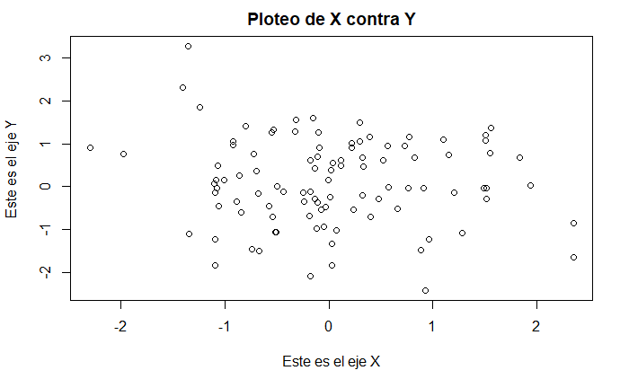

```r
x = rnorm(100)
y = rnorm(100)
plot(x,y,xlab="Este es el eje X",ylab="Este es el eje Y",main="Ploteo de X contra Y")
```

La función **seq()** nos permite crear un vector que contiene una secuencia de números específica. Por ejemplo **seq(a, b)** crea un vector con los números entre **a** y **b**. Si ingresamos **seq(0,1,length=10)** creamos una secuencia de **10** números que están separados equitativamente entre **0** y **1**. Escribir **3:11** es un atajo para escribir **seq(3,11)**.

```r
x=seq(1,10)
x
```

```
 [1]  1  2  3  4  5  6  7  8  9 10
```

```r
x = 1:10
x
```

```
 [1]  1  2  3  4  5  6  7  8  9 10
```

## Indexando datos

Supongamos que tenemos la siguiente matriz.

```r
A=matrix(1:16,4,4)
A
```

```
     [,1] [,2] [,3] [,4]
[1,]    1    5    9   13
[2,]    2    6   10   14
[3,]    3    7   11   15
[4,]    4    8   12   16
```

Si tipeamos **A[2,3]** vamos a acceder el elemento que reside en la segunda fila y la tercera columna.

```r
A[2,3]
```

```
[1] 10
```

El primer número luego del bracket **[** refiere a la fila y el segundo número a la columna. Para seleccionar varios valores al mismo tiempo, podemos proveer vectores como índices.

Seleccioná de la matriz **A**:

1. Los elementos de la fila 1 y 3 y la columna 2 y 4
2. Los elementos de la fila 1 a la 3 y de la fila 2 a la 4
3. Los elementos de la fila 1 a la 2 y todas las columnas
4. Todas las filas de las columnas 1 y 2

```r
A[c(1,3),c(2,4)]
```

```
     [,1] [,2]
[1,]    5   13
[2,]    7   15
```

```r
A[1:3,2:4]
```

```
     [,1] [,2] [,3]
[1,]    5    9   13
[2,]    6   10   14
[3,]    7   11   15
```

```r
A[1:2,]
```

```
     [,1] [,2] [,3] [,4]
[1,]    1    5    9   13
[2,]    2    6   10   14
```

```r
A[,1:2]
```

```
     [,1] [,2]
[1,]    1    5
[2,]    2    6
[3,]    3    7
[4,]    4    8
```

5. Todas las filas, menos la 1 y la 3 y todas las columnas
6. Todas las filas menos la 1 y la 3 y todas las columnas menos la 1, 3 y 4

```r
A[-c(1,3),]
```

```
     [,1] [,2] [,3] [,4]
[1,]    2    6   10   14
[2,]    4    8   12   16
```

```r
A[-c(1,3),-c(1,3,4)]
```

```
[1] 6 8
```

Con la función **dim()** devuelve la cantidad de filas seguida de la cantidad de columnas. A continuación utilizá **dim()** con la matriz **A**.

```r
dim(A)
```

```
[1] 4 4
```

## Cargando datos

Vamos a cargar el dataset que adjuntamos con este notebook, llamado “Auto.data”. Si lo abren, verán que es un archivo de texto plano, vamos a abrir el archivo usando **read.table()** pasandole los parámetros de **header** igual a **TRUE** y **na.strings** igual a **“?”**, lo que le va a indicar que a cada caracter particular (en este caso un signo de pregunta) lo trate como un valor perdido en la matriz de datos.

**fix()** se utiliza para visualizar la planilla como si fuera una panilla de cálculos de excel.

```r
Auto = read.table("../data/Auto.data", header=T, na.strings="?")
fix(Auto)
```

Ahora veamos las dimensiones de ‘Auto’.

```r
dim(Auto)
```

```
[1] 397   9
```

Usando la función **na.omit()** vamos a eliminar las observaciones que contienen valores perdidos, en este caso solo 5 observaciones contienen casos perdidos, por lo que nos deberíamos quedar con 392 observaciones.

```r
Auto=na.omit(Auto)
dim(Auto)
```

```
[1] 392   9
```

Chequeamos usando **names()** los nombres de las variables.

```r
names(Auto)
```

```
[1] "mpg"          "cylinders"    "displacement" "horsepower"   "weight"       "acceleration" "year"         "origin"       "name"
```

## Resúmenes gráficos y numéricos adicionales

A continuación generemos un scatterplot usando **plot()** pasando la variable **Cylinders** como variable independiente y **Mpg** como variable dependiente. Usando **attach()** le indicamos a *R* que cree una variable por cada variable del set de datos.

```r
attach(Auto)
```

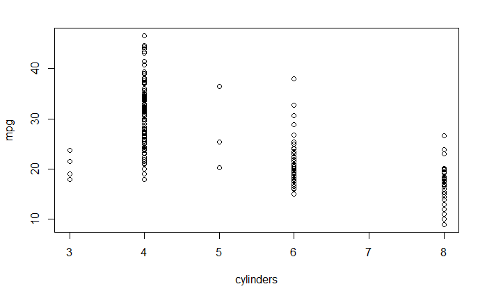

```r
plot(cylinders, mpg)
```

Transformemos la variable **cylinders** en una variable cualitativa. Luego, generemos un **plot()**, pasando nuevamente las variables **mpg** y **cylinder** que ahora es una variable cualitativa. Probemos diferentes parámetros para revisar qué gráficos obtenemos como resultado (recordá utilizar la ayuda **?plot**).

```r
cylinders=as.factor(cylinders)
```

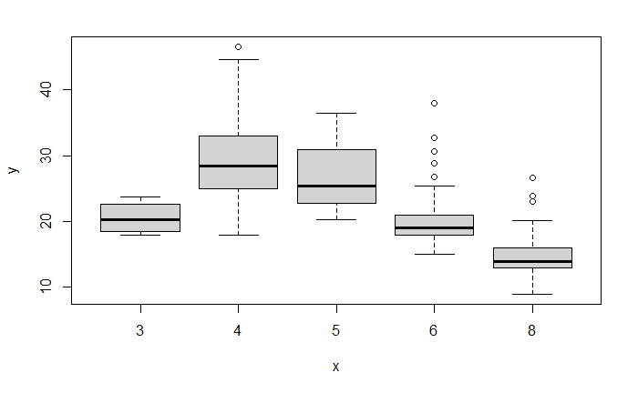

```r
plot(cylinders, mpg)
```

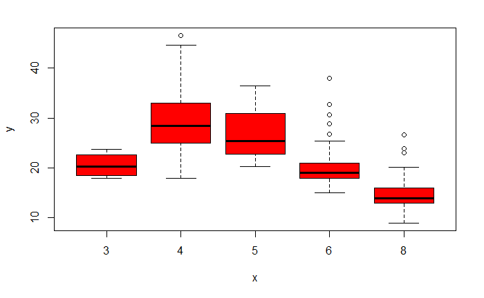

```r
plot(cylinders, mpg, col="red")
```

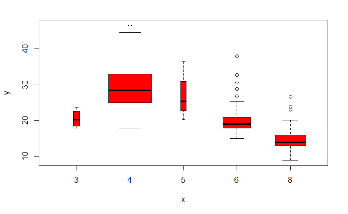

```r
plot(cylinders, mpg, col="red", varwidth=T)
```

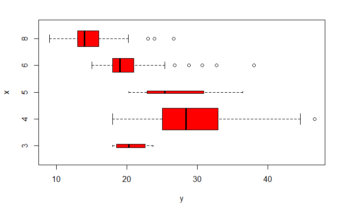

```r
plot(cylinders, mpg, col="red", varwidth=T,horizontal=T)
```

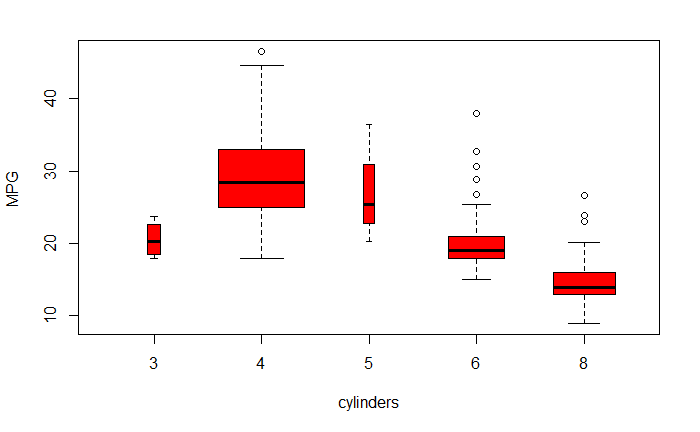

```r
plot(cylinders, mpg, col="red", varwidth=TRUE, xlab="cylinders", ylab ="MPG ")
```

Como vemos, al tener una variable cualitativa y una cuantitativa, **plot()** automáticamente genera **boxplots** por defecto.

Probemos ahora la función **hist()** para generar un histograma usando la matriz **Auto**. También probemos modificando diferentes parámetros.

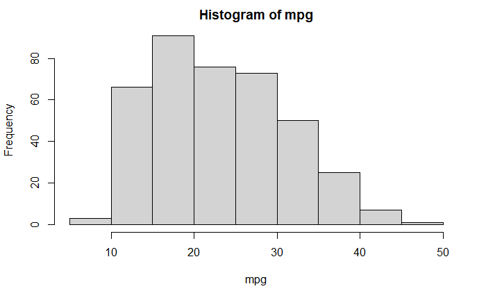

```r
hist(mpg)
```

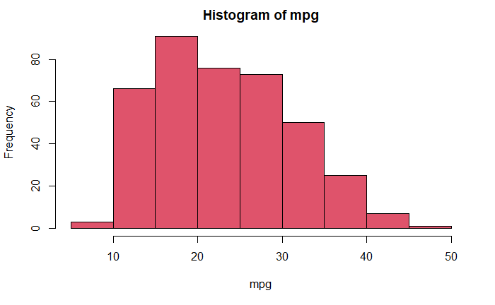

```r
hist(mpg,col=2)
```

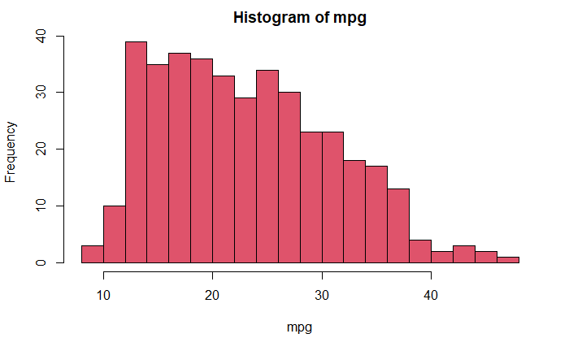

```r
hist(mpg,col=2,breaks=15)
```

Generemos ahora un gráfico usando **pairs()**, la cual crea una matriz de **scatterplots**. Usaremos un subconjunto de datos de la matriz principal, vamos a quedarnos solo con **mpg**, **displacement**, **horsepower**, **weight**, **acceleration**.

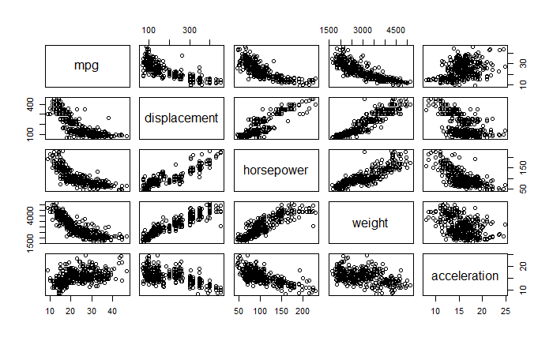

```r
pairs(∼ mpg + displacement + horsepower + weight +
acceleration , Auto)
```

[output not shown]

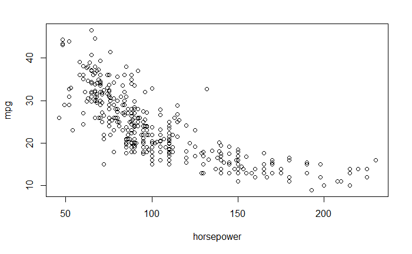

```r
plot(horsepower,mpg)
identify(horsepower,mpg,name)
```

Finalizamos usando la función **summary()** para tener un resumen de todos los datos que tenemos en la matriz de datos. También le podemos pasar variables para indagar sobre información puntual.

```r
summary(Auto)
```

```
      mpg          cylinders      displacement     horsepower        weight      acceleration        year           origin
 Min.   : 9.00   Min.   :3.000   Min.   : 68.0   Min.   : 46.0   Min.   :1613   Min.   : 8.00   Min.   :70.00   Min.   :1.000
 1st Qu.:17.00   1st Qu.:4.000   1st Qu.:105.0   1st Qu.: 75.0   1st Qu.:2225   1st Qu.:13.78   1st Qu.:73.00   1st Qu.:1.000
 Median :22.75   Median :4.000   Median :151.0   Median : 93.5   Median :2804   Median :15.50   Median :76.00   Median :1.000
 Mean   :23.45   Mean   :5.472   Mean   :194.4   Mean   :104.5   Mean   :2978   Mean   :15.54   Mean   :75.98   Mean   :1.577
 3rd Qu.:29.00   3rd Qu.:8.000   3rd Qu.:275.8   3rd Qu.:126.0   3rd Qu.:3615   3rd Qu.:17.02   3rd Qu.:79.00   3rd Qu.:2.000
 Max.   :46.60   Max.   :8.000   Max.   :455.0   Max.   :230.0   Max.   :5140   Max.   :24.80   Max.   :82.00   Max.   :3.000
     name
 Length:392
 Class :character
 Mode  :character
```

```r
summary(mpg)
```

```
   Min. 1st Qu.  Median    Mean 3rd Qu.    Max.
   9.00   17.00   22.75   23.45   29.00   46.60
```